# Predicting Employment Status from Lifestyle Factors (NHANES)

**Research question:** Can self-reported alcohol use and physical-activity behaviors predict whether a respondent is employed? We combine three NHANES modules (ALQ, OCQ, PAQ), build a binary classifier, and then test whether the signal is statistically real.

```python
import pandas as pd
import numpy as np
```

## 1. Data preparation

We load the three NHANES `.xpt` modules and outer-merge them on `SEQN` (respondent ID) so each respondent is a single row, even if present in only some modules.

```python
from pathlib import Path
from functools import reduce

modules = ["ALQ_L", "OCQ_L", "PAQ_L"]
dfs = [pd.read_sas(Path("data") / f"{m}.xpt", format="xport", encoding="utf-8") for m in modules]

df = reduce(lambda left, right: pd.merge(left, right, on="SEQN", how="outer"), dfs)

print(df.shape)
df.head()
```

```
(8501, 21)
```

|  | SEQN | ALQ111 | ALQ121 | ALQ130 | ALQ142 | ALQ270 | ALQ280 | ALQ151 | ALQ170 | OCD150 | ... | OCQ210 | OCQ215 | OCQ383 | PAD790Q | PAD790U | PAD800 | PAD810Q | PAD810U | PAD820 | PAD680 |
| --- | --- | --- | --- | --- | --- | --- | --- | --- | --- | --- | --- | --- | --- | --- | --- | --- | --- | --- | --- | --- | --- |
| 0 | 130378.0 | NaN | NaN | NaN | NaN | NaN | NaN | NaN | NaN | 1.0 | ... | NaN | 5.0 | NaN | 3.000000e+00 | W | 45.0 | 3.000000e+00 | W | 45.0 | 360.0 |
| 1 | 130379.0 | 1.0 | 2.0 | 3.0 | 5.397605e-79 | NaN | NaN | 2.0 | NaN | 1.0 | ... | 2.0 | 3.0 | NaN | 4.000000e+00 | W | 45.0 | 3.000000e+00 | W | 45.0 | 480.0 |
| 2 | 130380.0 | 1.0 | 10.0 | 1.0 | 5.397605e-79 | NaN | NaN | 2.0 | NaN | 1.0 | ... | 2.0 | 2.0 | NaN | 1.000000e+00 | W | 20.0 | 5.397605e-79 |  | NaN | 240.0 |
| 3 | 130384.0 | NaN | NaN | NaN | NaN | NaN | NaN | NaN | NaN | 1.0 | ... | NaN | 7.0 | NaN | 5.397605e-79 |  | NaN | 5.397605e-79 |  | NaN | 60.0 |
| 4 | 130385.0 | NaN | NaN | NaN | NaN | NaN | NaN | NaN | NaN | 4.0 | ... | NaN | NaN | 1.0 | 1.000000e+00 | D | 90.0 | 1.000000e+00 | W | 60.0 | 180.0 |

5 rows × 21 columns

`pandas.read_sas` decodes the value 0 in XPORT files as a tiny float (~5.4e-79); we restore those to a true 0, since the codebook confirms 0 is a valid response.

```python
# Fix a pandas.read_sas xport quirk: the value 0 is decoded as ~5.4e-79.
# Restore those to 0 across numeric columns (doc.md confirms 0 is a valid code).
num_cols = df.select_dtypes(include="number").columns
df[num_cols] = df[num_cols].mask(df[num_cols].abs() < 1e-12, 0.0)
```

NHANES encodes "Refused"/"Don't know" as runs of 7s and 9s (e.g. 7/9, or 7777/9999 for wider ranges). We detect and convert these to missing so they aren't treated as real values.

```python
# Remove NHANES "Refused" (repeated 7s) and "Don't know" (repeated 9s) codes.
# For each column the code is the shortest run of 7s / 9s that exceeds every
# real value, e.g. 7/9 for codes 1-4, or 7777/9999 for a 0-1320 range.
def is_run(x, d):
    return x == int(x) and x > 0 and set(str(int(x))) == {d}

def special_codes(s):
    vals = s.dropna().unique()
    real = [v for v in vals if not is_run(v, "7") and not is_run(v, "9")]
    max_real = max(real) if real else 0
    refused = next((int("7" * w) for w in range(1, 10) if int("7" * w) > max_real), None)
    dont_know = next((int("9" * w) for w in range(1, 10) if int("9" * w) > max_real), None)
    return refused, dont_know

for col in df.columns.drop("SEQN"):
    if np.issubdtype(df[col].dtype, np.number):
        refused, dont_know = special_codes(df[col])
        df[col] = df[col].replace({refused: np.nan, dont_know: np.nan})

print(df.shape)
```

```
(8501, 21)
```

We recode raw survey codes into interpretable units (yes/no → 1/0, alcohol-frequency codes → drinking days/year, activity frequency×duration → minutes/week), and apply NHANES skip-pattern logic where an upstream "no" implies a structural 0 rather than missing.

```python
# ---- Recode variables into meaningful units (per doc.md) ----

# Yes/No -> 1/0
for col in ["ALQ111", "ALQ151"]:
    df[col] = df[col].map({1: 1, 2: 0})

# Alcohol frequency code (0-10, same scheme across these four) -> drinking days/year.
# "Nearly every day" = 300; your example's 365/2 collided with code 3. Tune freely.
FREQ_TO_DAYS = {
    0: 0, 1: 365, 2: 300, 3: 3.5 * 52.18, 4: 2 * 52.18, 5: 52.18,
    6: 2.5 * 12, 7: 12, 8: 9, 9: 4.5, 10: 1.5,
}
for col in ["ALQ121", "ALQ142", "ALQ270", "ALQ280"]:
    df[col] = df[col].map(FREQ_TO_DAYS)

# ALQ130 (drinks/occasion) and ALQ170 (binge count, past 30 days) are already
# meaningful counts -> kept as-is and separate.

# Physical activity: frequency x unit x per-session minutes -> minutes/week.
UNIT_PER_WK = {"D": 7.0, "W": 1.0, "M": 12 / 52.1775, "Y": 1 / 52.1775}
def min_per_week(freq, unit, dur):
    mins = df[freq] * df[unit].map(UNIT_PER_WK) * df[dur]
    mins[df[freq] == 0] = 0.0  # never does it -> 0 (unit/duration are skipped)
    return mins
df["MOD_MIN_WK"] = min_per_week("PAD790Q", "PAD790U", "PAD800")
df["VIG_MIN_WK"] = min_per_week("PAD810Q", "PAD810U", "PAD820")
df = df.drop(columns=["PAD790Q", "PAD790U", "PAD800", "PAD810Q", "PAD810U", "PAD820"])
# PAD680 (sedentary min/day) is already clean -> kept.

# Structural zeros: NHANES skip patterns imply 0, not "missing".
df.loc[df["ALQ111"] == 0, ["ALQ121", "ALQ130", "ALQ142", "ALQ270", "ALQ280", "ALQ170", "ALQ151"]] = 0
df.loc[df["ALQ121"] == 0, ["ALQ130", "ALQ142", "ALQ270", "ALQ280", "ALQ170"]] = 0

print(df.shape)
```

```
(8501, 17)
```

We tally remaining missingness per column to judge which variables are usable and how much imputation each needs.

```python
null_summary = df.isnull().sum().rename("null_count")
null_summary.to_frame()
```

|  | null_count |
| --- | --- |
| SEQN | 0 |
| ALQ111 | 3025 |
| ALQ121 | 3026 |
| ALQ130 | 3038 |
| ALQ142 | 3045 |
| ALQ270 | 4754 |
| ALQ280 | 4755 |
| ALQ151 | 3048 |
| ALQ170 | 4749 |
| OCD150 | 18 |
| OCQ180 | 4254 |
| OCQ210 | 7062 |
| OCQ215 | 4227 |
| OCQ383 | 5083 |
| PAD680 | 436 |
| MOD_MIN_WK | 415 |
| VIG_MIN_WK | 403 |

A correlation heatmap helps us spot redundant features (e.g. related alcohol-frequency variables) before modeling.

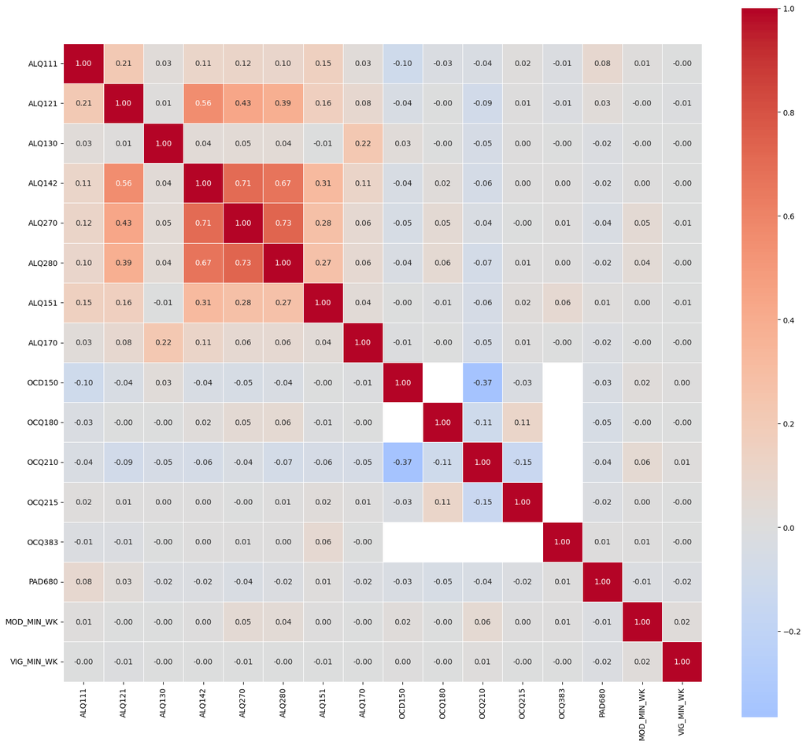

```python
import seaborn as sns
import matplotlib.pyplot as plt

df_num = df.select_dtypes(include="number").drop(columns="SEQN").round(2)

corr = df_num.corr()

fig, ax = plt.subplots(figsize=(16, 14))
sns.heatmap(corr, annot=True, fmt=".2f", cmap="coolwarm", center=0,
            square=True, linewidths=0.5, ax=ax)
plt.tight_layout()
plt.show()
```

## 2. Building the modeling dataset

We define the target from `OCD150`: **employed** = currently working or has a job but absent; **not employed** = everyone else. Critically, we first **exclude retirees** (`OCD150 == 4` with reason `OCQ383 == 3`), since retirement is age-driven and would otherwise make the model detect age rather than employment. The remaining "not employed" class still mixes job-seekers with disabled/student/homemaker respondents, so we read it as "not employed (excl. retired)" rather than strict unemployment. We then drop rows with no employment label and remove leaky/duplicative occupation columns, leaving the numeric lifestyle variables as features `X`.

```python
from sklearn.model_selection import train_test_split
from sklearn.impute import SimpleImputer

df_ml = df.select_dtypes(include="number").drop(columns="SEQN")

# Exclude retirees: not working (OCD150 == 4) whose reason (OCQ383) is "Retired" (== 3).
# Retirement is age-driven, so keeping them would make the model detect age, not employment.
# (Code-3 "looking for work" people have OCQ383 = NaN via the skip pattern, so this mask
# only catches code-4 retirees.)
df_ml = df_ml[~((df_ml["OCD150"] == 4) & (df_ml["OCQ383"] == 3))]

# Employed = working (1) or has a job but absent (2); everyone else not working is "not
# employed" (looking for work, disabled, student, homemaker, etc. -- retirees excluded above).
target_map = {1: "employed", 2: "employed", 3: "unemployed", 4: "unemployed"}
df_ml["OCD150"] = df_ml["OCD150"].map(target_map)
df_ml = df_ml.dropna(subset=["OCD150"]).drop(columns=["OCQ210","OCQ383", "OCQ180", "OCQ215"], errors="ignore")

X = df_ml.drop(columns="OCD150")
y = df_ml["OCD150"]

print(y.value_counts())
```

```
OCD150
employed      4509
unemployed    1986
Name: count, dtype: int64
```

We check multicollinearity with VIF, iteratively dropping any feature with VIF > 5 (protecting `PAD680`), since collinearity would destabilize the logistic-regression coefficients we interpret later.

```python
from statsmodels.stats.outliers_influence import variance_inflation_factor

# VIF needs complete data, so work on a median-imputed copy of the features.
# (The real pipeline imputes after the train/test split below.)
X_vif = X.fillna(X.median())

# Report highly correlated pairs for intuition (e.g. ALQ121 / ALQ280).
c = X.corr().abs()
pairs = c.where(np.triu(np.ones(c.shape), k=1).astype(bool)).stack()
print("Correlated pairs (|r| > 0.8):")
print(pairs[pairs > 0.8].sort_values(ascending=False).to_string() or "  none")

# Iteratively drop the highest-VIF feature until all <= 5; never drop PAD680.
PROTECTED = {"PAD680"}
features = list(X_vif.columns)
dropped = []
while True:
    vif = pd.Series([variance_inflation_factor(X_vif[features].values, i)
                     for i in range(len(features))], index=features)
    candidates = vif.drop(index=PROTECTED & set(features))
    if candidates.max() <= 5:
        break
    worst = candidates.idxmax()
    dropped.append((worst, round(candidates.max(), 2)))
    features.remove(worst)

print("\nDropped (feature, VIF at removal):", dropped or "none")
print("\nFinal VIF:")
print(vif.sort_values(ascending=False).round(2).to_string())

X = X[features]
```

```
Correlated pairs (|r| > 0.8):
Series([], )

Dropped (feature, VIF at removal): none

Final VIF:
ALQ111        3.78
PAD680        3.48
ALQ142        3.45
ALQ270        3.00
ALQ280        2.68
ALQ121        2.14
ALQ151        1.30
ALQ130        1.23
ALQ170        1.22
MOD_MIN_WK    1.00
VIG_MIN_WK    1.00
```

We split 80/20 and fit the median imputer on the training set only, then apply it to the test set, to avoid leaking test information into preprocessing.

```python
X_train, X_test, y_train, y_test = train_test_split(X, y, test_size=0.2, random_state=42)

imputer = SimpleImputer(strategy="median")
X_train = pd.DataFrame(imputer.fit_transform(X_train), columns=X.columns)
X_test = pd.DataFrame(imputer.transform(X_test), columns=X.columns)
```

## 3. Training and comparing models

We start with a class-balanced Random Forest as a strong, low-tuning baseline and inspect its precision/recall and confusion matrix.

```
              precision    recall  f1-score   support

    employed       0.75      0.81      0.78       897
  unemployed       0.48      0.39      0.43       402

    accuracy                           0.68      1299
   macro avg       0.62      0.60      0.60      1299
weighted avg       0.67      0.68      0.67      1299
```

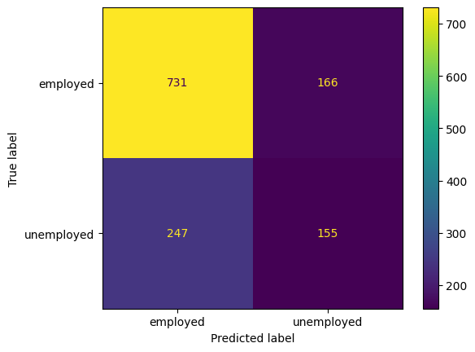

```python
from sklearn.ensemble import RandomForestClassifier
from sklearn.metrics import classification_report, ConfusionMatrixDisplay

rf = RandomForestClassifier(class_weight="balanced", random_state=42)
rf.fit(X_train, y_train)

print(classification_report(y_test, rf.predict(X_test)))
ConfusionMatrixDisplay.from_estimator(rf, X_test, y_test)
plt.show()
```

We read the Random Forest's importances two ways — built-in Gini and permutation importance — since the two can disagree when features are correlated.

```python
from sklearn.inspection import permutation_importance

gini = pd.Series(rf.feature_importances_, index=X.columns)

perm = permutation_importance(rf, X_test, y_test, random_state=42)
perm = pd.Series(perm.importances_mean, index=X.columns)

importances = pd.DataFrame({"gini": gini, "permutation": perm}).sort_values("permutation", ascending=False)
importances
```

|  | gini | permutation |
| --- | --- | --- |
| VIG_MIN_WK | 0.185380 | 1.755196e-02 |
| MOD_MIN_WK | 0.278853 | 7.544265e-03 |
| PAD680 | 0.210344 | 4.618938e-03 |
| ALQ142 | 0.045401 | 1.539646e-03 |
| ALQ280 | 0.023356 | -2.220446e-17 |
| ALQ111 | 0.007629 | -1.385681e-03 |
| ALQ170 | 0.029522 | -1.847575e-03 |
| ALQ151 | 0.017434 | -3.079292e-03 |
| ALQ270 | 0.034414 | -3.849115e-03 |
| ALQ121 | 0.095667 | -4.618938e-03 |
| ALQ130 | 0.072001 | -4.926867e-03 |

We try KNN, scaling features first because distance-based methods are sensitive to feature scale.

```python
from sklearn.preprocessing import StandardScaler
from sklearn.neighbors import KNeighborsClassifier

scaler = StandardScaler()
X_train_s = scaler.fit_transform(X_train)
X_test_s = scaler.transform(X_test)

knn = KNeighborsClassifier()
knn.fit(X_train_s, y_train)

print(classification_report(y_test, knn.predict(X_test_s)))
```

```
              precision    recall  f1-score   support

    employed       0.72      0.82      0.77       897
  unemployed       0.43      0.29      0.35       402

    accuracy                           0.66      1299
   macro avg       0.57      0.56      0.56      1299
weighted avg       0.63      0.66      0.64      1299
```

We fit a logistic regression as an interpretable linear baseline whose coefficients we examine later.

```python
from sklearn.linear_model import LogisticRegression

lr = LogisticRegression(class_weight="balanced", max_iter=1000)
lr.fit(X_train_s, y_train)

print(classification_report(y_test, lr.predict(X_test_s)))
```

```
              precision    recall  f1-score   support

    employed       0.78      0.38      0.51       897
  unemployed       0.35      0.76      0.48       402

    accuracy                           0.50      1299
   macro avg       0.57      0.57      0.50      1299
weighted avg       0.65      0.50      0.50      1299
```

We add gradient boosting, which often captures nonlinear interactions the other models miss.

```python
from sklearn.ensemble import HistGradientBoostingClassifier

gb = HistGradientBoostingClassifier(class_weight="balanced", random_state=42)
gb.fit(X_train, y_train)

print(classification_report(y_test, gb.predict(X_test)))
```

```
              precision    recall  f1-score   support

    employed       0.79      0.68      0.73       897
  unemployed       0.45      0.60      0.52       402

    accuracy                           0.65      1299
   macro avg       0.62      0.64      0.62      1299
weighted avg       0.69      0.65      0.66      1299
```

We compare all four models side by side on accuracy and macro-F1, against a majority-class baseline (the no-information rate). A model is only useful if it clears that baseline by a meaningful margin.

```python
from sklearn.metrics import accuracy_score, f1_score
from sklearn.dummy import DummyClassifier

# Majority-class baseline: always predict the most frequent class. This is the
# no-information rate that the real models must beat to be useful.
dummy = DummyClassifier(strategy="most_frequent").fit(X_train, y_train)

results = {
    "Baseline (majority)": dummy.predict(X_test),
    "RandomForest": rf.predict(X_test),
    "KNN": knn.predict(X_test_s),
    "LogisticRegression": lr.predict(X_test_s),
    "GradientBoosting": gb.predict(X_test),
}

pd.DataFrame({
    name: {
        "accuracy": accuracy_score(y_test, pred),
        "macro_f1": f1_score(y_test, pred, average="macro"),
    }
    for name, pred in results.items()
}).T
```

|  | accuracy | macro_f1 |
| --- | --- | --- |
| Baseline (majority) | 0.690531 | 0.408470 |
| RandomForest | 0.682063 | 0.604251 |
| KNN | 0.658968 | 0.557517 |
| LogisticRegression | 0.498845 | 0.498370 |
| GradientBoosting | 0.652810 | 0.623225 |

## 4. Interpreting feature importance

```
intercept: -0.02343583480171029
classes: ['employed' 'unemployed']
```

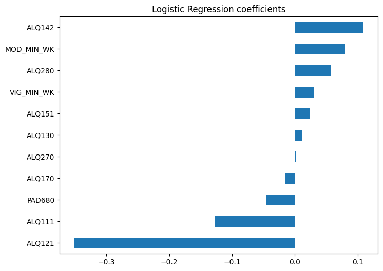

```python
# Logistic Regression: signed coefficients (the model itself).
# log-odds = intercept + sum(coef * feature); positive pushes toward one class.
print("intercept:", lr.intercept_[0])
print("classes:", lr.classes_)

coef = pd.Series(lr.coef_[0], index=X.columns).sort_values()
coef.plot.barh(figsize=(8, 6), title="Logistic Regression coefficients")
plt.show()
```

KNN and gradient boosting lack usable built-in importances, so we use model-agnostic permutation importance for both.

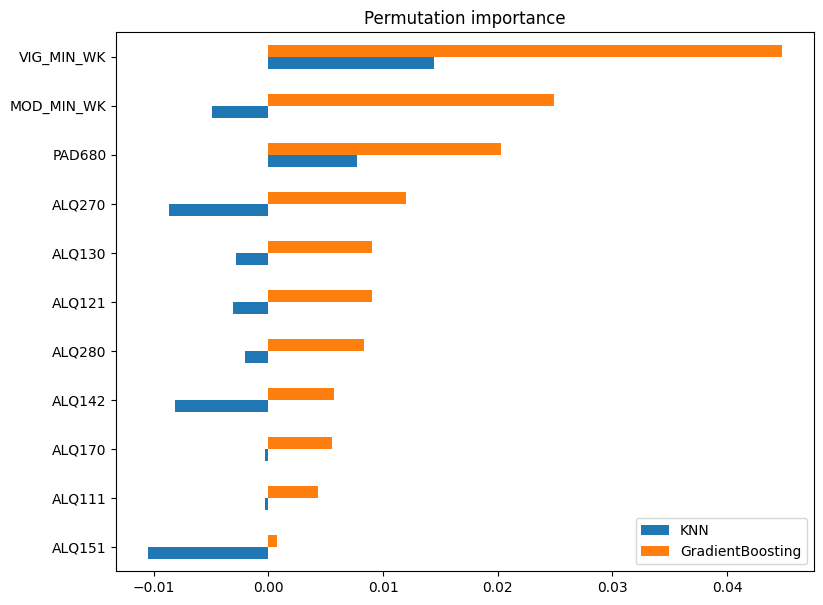

```python
# KNN and Gradient Boosting have no usable built-in importances,
# so use permutation importance (model-agnostic). KNN uses scaled data.
knn_imp = permutation_importance(knn, X_test_s, y_test, random_state=42).importances_mean
gb_imp = permutation_importance(gb, X_test, y_test, random_state=42).importances_mean

perm_df = pd.DataFrame({"KNN": knn_imp, "GradientBoosting": gb_imp}, index=X.columns)
perm_df.sort_values("GradientBoosting").plot.barh(figsize=(9, 7), title="Permutation importance")
plt.show()
```

We assemble every model's importances into one table; because they're on different scales and signs, we normalize each by its max absolute value and average for an overall ranking.

```python
imp = pd.DataFrame({
    "RandomForest": rf.feature_importances_,
    "KNN": knn_imp,
    "GradientBoosting": gb_imp,
    "LogisticRegression": lr.coef_[0],
}, index=X.columns)

# Columns are on different scales/signs, so normalize each by its max
# absolute value, then average to rank overall importance.
avg = imp.abs().div(imp.abs().max()).mean(axis=1)
imp["avg_importance"] = avg
imp.sort_values("avg_importance", ascending=False)
```

|  | RandomForest | KNN | GradientBoosting | LogisticRegression | avg_importance |
| --- | --- | --- | --- | --- | --- |
| VIG_MIN_WK | 0.185380 | 0.014473 | 0.044804 | 0.030684 | 0.688031 |
| MOD_MIN_WK | 0.278853 | -0.004927 | 0.024942 | 0.079653 | 0.530956 |
| PAD680 | 0.210344 | 0.007698 | 0.020323 | -0.045214 | 0.467131 |
| ALQ121 | 0.095667 | -0.003079 | 0.009084 | -0.351362 | 0.439647 |
| ALQ142 | 0.045401 | -0.008160 | 0.005697 | 0.109511 | 0.291367 |
| ALQ270 | 0.034414 | -0.008622 | 0.012009 | 0.001477 | 0.247851 |
| ALQ151 | 0.017434 | -0.010470 | 0.000770 | 0.023510 | 0.217504 |
| ALQ130 | 0.072001 | -0.002771 | 0.009084 | 0.012071 | 0.171699 |
| ALQ280 | 0.023356 | -0.002002 | 0.008314 | 0.057404 | 0.142749 |
| ALQ111 | 0.007629 | -0.000308 | 0.004311 | -0.128231 | 0.127452 |
| ALQ170 | 0.029522 | -0.000308 | 0.005543 | -0.016184 | 0.074229 |

We show the same ranking with each model column explicitly normalized, making the averaging step transparent.

```python
# Same data, but every model column normalized (|value| / max|value|),
# so avg_importance is simply the row mean of these four columns.
models = ["RandomForest", "KNN", "GradientBoosting", "LogisticRegression"]
norm = imp[models].abs().div(imp[models].abs().max())
norm["avg_importance"] = norm.mean(axis=1)
norm.sort_values("avg_importance", ascending=False)
```

|  | RandomForest | KNN | GradientBoosting | LogisticRegression | avg_importance |
| --- | --- | --- | --- | --- | --- |
| VIG_MIN_WK | 0.664797 | 1.000000 | 1.000000 | 0.087329 | 0.688031 |
| MOD_MIN_WK | 1.000000 | 0.340426 | 0.556701 | 0.226697 | 0.530956 |
| PAD680 | 0.754319 | 0.531915 | 0.453608 | 0.128681 | 0.467131 |
| ALQ121 | 0.343072 | 0.212766 | 0.202749 | 1.000000 | 0.439647 |
| ALQ142 | 0.162814 | 0.563830 | 0.127148 | 0.311677 | 0.291367 |
| ALQ270 | 0.123414 | 0.595745 | 0.268041 | 0.004205 | 0.247851 |
| ALQ151 | 0.062521 | 0.723404 | 0.017182 | 0.066911 | 0.217504 |
| ALQ130 | 0.258204 | 0.191489 | 0.202749 | 0.034354 | 0.171699 |
| ALQ280 | 0.083756 | 0.138298 | 0.185567 | 0.163375 | 0.142749 |
| ALQ111 | 0.027359 | 0.021277 | 0.096220 | 0.364954 | 0.127452 |
| ALQ170 | 0.105868 | 0.021277 | 0.123711 | 0.046061 | 0.074229 |

## 5. Hypothesis testing

Beyond prediction, we ask which associations are statistically significant: we fit a logistic regression, run an omnibus likelihood-ratio test (does *any* feature predict employment?), then per-feature Wald tests with odds ratios and FDR correction for multiple comparisons.

```python
import statsmodels.api as sm
from statsmodels.stats.multitest import multipletests

# Outcome as 0/1 (employed = 1), features median-imputed to keep the full sample.
# Note: imputation makes standard errors slightly optimistic vs. complete-case.
y01 = (y == "employed").astype(int)
X_test_hyp = sm.add_constant(X.fillna(X.median()))

result = sm.Logit(y01, X_test_hyp).fit(disp=False)

# 1. Omnibus likelihood-ratio test: H0 = no feature predicts employment.
print(f"n = {int(result.nobs)}")
print(f"Omnibus LR test: chi2 = {result.llr:.1f}, p = {result.llr_pvalue:.3e}")
print(f"McFadden pseudo-R^2 = {result.prsquared:.3f}")
print("=> reject H0; at least one feature predicts employment"
      if result.llr_pvalue < 0.05 else "=> fail to reject H0")

# 2. Per-feature Wald tests, with odds ratios, CIs, and FDR correction.
ci = result.conf_int()
table = pd.DataFrame({
    "coef": result.params,
    "odds_ratio": np.exp(result.params),
    "or_ci_low": np.exp(ci[0]),
    "or_ci_high": np.exp(ci[1]),
    "p_value": result.pvalues,
}).drop(index="const")
table["p_value_fdr"] = multipletests(table["p_value"], method="fdr_bh")[1]
table["significant"] = table["p_value_fdr"] < 0.05
table.sort_values("p_value").round(4)
```

```
n = 6495
Omnibus LR test: chi2 = 144.9, p = 1.612e-25
McFadden pseudo-R^2 = 0.018
=> reject H0; at least one feature predicts employment
```

|  | coef | odds_ratio | or_ci_low | or_ci_high | p_value | p_value_fdr | significant |
| --- | --- | --- | --- | --- | --- | --- | --- |
| ALQ121 | 0.0049 | 1.0049 | 1.0037 | 1.0061 | 0.0000 | 0.0000 | True |
| ALQ111 | 0.5394 | 1.7149 | 1.3953 | 2.1078 | 0.0000 | 0.0000 | True |
| ALQ142 | -0.0025 | 0.9975 | 0.9950 | 1.0000 | 0.0482 | 0.1766 | False |
| ALQ151 | -0.1440 | 0.8659 | 0.7223 | 1.0380 | 0.1194 | 0.2763 | False |
| PAD680 | 0.0002 | 1.0002 | 0.9999 | 1.0005 | 0.1366 | 0.2763 | False |
| MOD_MIN_WK | -0.0000 | 1.0000 | 1.0000 | 1.0000 | 0.1507 | 0.2763 | False |
| ALQ280 | -0.0018 | 0.9982 | 0.9949 | 1.0016 | 0.3067 | 0.4820 | False |
| VIG_MIN_WK | -0.0000 | 1.0000 | 1.0000 | 1.0000 | 0.3825 | 0.5259 | False |
| ALQ170 | 0.0006 | 1.0006 | 0.9974 | 1.0039 | 0.7081 | 0.7932 | False |
| ALQ270 | -0.0005 | 0.9995 | 0.9964 | 1.0027 | 0.7739 | 0.7932 | False |
| ALQ130 | -0.0003 | 0.9997 | 0.9975 | 1.0019 | 0.7932 | 0.7932 | False |

Finally, we permutation-test the three non-linear models: by repeatedly shuffling the labels we build a null distribution of scores and check whether each model's real cross-validated performance beats chance.

```python
from sklearn.model_selection import permutation_test_score, StratifiedKFold, cross_val_score
from sklearn.pipeline import make_pipeline
from IPython.display import display

# Pipelines so imputation (and scaling for KNN) happen inside each CV fold.
cv = StratifiedKFold(n_splits=5, shuffle=True, random_state=42)
models = {
    "RandomForest": make_pipeline(
        SimpleImputer(strategy="median"),
        RandomForestClassifier(class_weight="balanced", random_state=42)),
    "KNN": make_pipeline(
        SimpleImputer(strategy="median"), StandardScaler(),
        KNeighborsClassifier()),
    "GradientBoosting": make_pipeline(
        SimpleImputer(strategy="median"),
        HistGradientBoostingClassifier(class_weight="balanced", random_state=42)),
}

# H0: the model predicts no better than chance (labels shuffled).
# permutation_test_score scores one metric (f1_macro); accuracy is added via a
# plain cross_val_score on the same folds (classes are ~balanced, so it's useful too).
perm_results = {}
for name, model in models.items():
    print(f"Running {name}...")
    score, _, pvalue = permutation_test_score(
        model, X, y, scoring="f1_macro", cv=cv,
        n_permutations=100, n_jobs=-1, random_state=42, verbose=0)
    accuracy = cross_val_score(model, X, y, scoring="accuracy", cv=cv, n_jobs=-1).mean()
    perm_results[name] = {"accuracy": accuracy, "f1_macro": score, "p_value": pvalue}

perm_df = pd.DataFrame(perm_results).T
display(perm_df)
```

```
Running RandomForest...
Running KNN...
Running GradientBoosting...
```

|  | accuracy | f1_macro | p_value |
| --- | --- | --- | --- |
| RandomForest | 0.682833 | 0.607893 | 0.009901 |
| KNN | 0.666975 | 0.566103 | 0.009901 |
| GradientBoosting | 0.642494 | 0.610906 | 0.009901 |

## 6. Sensitivity analysis: does the target definition drive the result?

We re-run the models under two targets to see how much the conclusion depends on how retirees are treated: **(A)** employed vs not-employed, *excluding* retirees (our primary analysis), and **(B)** working vs not working, *including* retirees. If B looks much stronger, that gain reflects reintroduced age/life-stage signal and class rebalancing (the classes shift from ≈69/31 to ≈53/47) — not a genuinely stronger lifestyle effect.

```python
# Build (X, y) for either target definition straight from the cleaned df.
# The feature set matches the primary analysis (the VIF step dropped nothing).
def build_xy(drop_retirees: bool):
    d = df.select_dtypes(include="number").drop(columns="SEQN").copy()
    if drop_retirees:  # Definition A: drop retirees (OCD150 == 4 & OCQ383 == 3)
        d = d[~((d["OCD150"] == 4) & (d["OCQ383"] == 3))]
    target_map = {1: "working", 2: "working", 3: "not_working", 4: "not_working"}
    d["OCD150"] = d["OCD150"].map(target_map)
    d = d.dropna(subset=["OCD150"]).drop(
        columns=["OCQ210", "OCQ383", "OCQ180", "OCQ215"], errors="ignore")
    return d.drop(columns="OCD150"), d["OCD150"]

def make_models():  # same model zoo, each wrapped so impute/scale happen in-fold
    return {
        "RandomForest": make_pipeline(SimpleImputer(strategy="median"),
            RandomForestClassifier(class_weight="balanced", random_state=42)),
        "KNN": make_pipeline(SimpleImputer(strategy="median"), StandardScaler(),
            KNeighborsClassifier()),
        "LogisticRegression": make_pipeline(SimpleImputer(strategy="median"), StandardScaler(),
            LogisticRegression(class_weight="balanced", max_iter=1000)),
        "GradientBoosting": make_pipeline(SimpleImputer(strategy="median"),
            HistGradientBoostingClassifier(class_weight="balanced", random_state=42)),
    }

cv = StratifiedKFold(n_splits=5, shuffle=True, random_state=42)
definitions = {"A: excl. retirees": True, "B: incl. retirees": False}

rows = []
for label, drop_ret in definitions.items():
    Xd, yd = build_xy(drop_ret)
    baseline = yd.value_counts(normalize=True).max()  # majority-class accuracy
    for name, model in make_models().items():
        acc = cross_val_score(model, Xd, yd, scoring="accuracy", cv=cv, n_jobs=-1).mean()
        f1 = cross_val_score(model, Xd, yd, scoring="f1_macro", cv=cv, n_jobs=-1).mean()
        rows.append({"definition": label, "n": len(yd), "pct_working": (yd == "working").mean(),
                     "baseline_acc": baseline, "model": name, "cv_accuracy": acc, "cv_macro_f1": f1})

sens = pd.DataFrame(rows)
display(sens.groupby("definition")[["n", "pct_working", "baseline_acc"]].first().round(3))
display(sens.pivot(index="model", columns="definition",
                   values=["cv_accuracy", "cv_macro_f1"]).round(3))
```

| definition | n | pct_working | baseline_acc |
| --- | --- | --- | --- |
| A: excl. retirees | 6495 | 0.694 | 0.694 |
| B: incl. retirees | 8483 | 0.532 | 0.532 |

| definition model | cv_accuracy A: excl. retirees | cv_accuracy B: incl. retirees | cv_macro_f1 A: excl. retirees | cv_macro_f1 B: incl. retirees |
| --- | --- | --- | --- | --- |
| GradientBoosting | 0.642 | 0.620 | 0.611 | 0.620 |
| KNN | 0.667 | 0.574 | 0.566 | 0.571 |
| LogisticRegression | 0.493 | 0.545 | 0.492 | 0.544 |
| RandomForest | 0.682 | 0.607 | 0.608 | 0.605 |

## 7. Bonus: can we predict retirement status?

```python
from sklearn.dummy import DummyClassifier

# Target: retired = not working (OCD150 == 4) for reason "Retired" (OCQ383 == 3);
# everyone else with a known work status = not retired. Features stay the lifestyle
# variables only (occupation columns dropped), so there is no label leakage.
d = df.select_dtypes(include="number").drop(columns="SEQN").copy()
d = d[d["OCD150"].notna()]
y_ret = pd.Series(
    np.where((d["OCD150"] == 4) & (d["OCQ383"] == 3), "retired", "not_retired"),
    index=d.index, name="retirement")
X_ret = d.drop(columns=["OCD150", "OCQ210", "OCQ383", "OCQ180", "OCQ215"], errors="ignore")

print(y_ret.value_counts())

# Same model zoo plus a majority-class baseline, scored under the same 5-fold CV.
models_ret = {
    "Baseline (majority)": make_pipeline(
        SimpleImputer(strategy="median"), DummyClassifier(strategy="most_frequent")),
    **make_models(),
}
rows = []
for name, model in models_ret.items():
    acc = cross_val_score(model, X_ret, y_ret, scoring="accuracy", cv=cv, n_jobs=-1).mean()
    f1 = cross_val_score(model, X_ret, y_ret, scoring="f1_macro", cv=cv, n_jobs=-1).mean()
    rows.append({"model": name, "cv_accuracy": acc, "cv_macro_f1": f1})

display(pd.DataFrame(rows).set_index("model").round(3))
```

```
retirement
not_retired    6495
retired        1988
Name: count, dtype: int64
```

| model | cv_accuracy | cv_macro_f1 |
| --- | --- | --- |
| Baseline (majority) | 0.766 | 0.434 |
| RandomForest | 0.715 | 0.588 |
| KNN | 0.727 | 0.555 |
| LogisticRegression | 0.576 | 0.504 |
| GradientBoosting | 0.648 | 0.604 |

```python
# Is the retirement signal real, and which behaviors drive it?
# (1) Permutation test on the strongest model.
gb_ret = make_pipeline(
    SimpleImputer(strategy="median"),
    HistGradientBoostingClassifier(class_weight="balanced", random_state=42))
score, _, pvalue = permutation_test_score(
    gb_ret, X_ret, y_ret, scoring="f1_macro", cv=cv,
    n_permutations=100, n_jobs=-1, random_state=42)
print(f"GradientBoosting f1_macro = {score:.3f}, permutation p = {pvalue:.4f}")

# (2) Logistic-regression odds ratios: which lifestyle features associate with being retired.
y_ret01 = (y_ret == "retired").astype(int)
Xh = sm.add_constant(X_ret.fillna(X_ret.median()))
res_ret = sm.Logit(y_ret01, Xh).fit(disp=False)
print(f"n = {int(res_ret.nobs)}, "
      f"omnibus p = {res_ret.llr_pvalue:.2e}, McFadden pseudo-R^2 = {res_ret.prsquared:.3f}")

or_table = pd.DataFrame({
    "odds_ratio": np.exp(res_ret.params),
    "p_value": res_ret.pvalues,
}).drop(index="const")
or_table["p_value_fdr"] = multipletests(or_table["p_value"], method="fdr_bh")[1]
or_table["significant"] = or_table["p_value_fdr"] < 0.05
or_table.sort_values("p_value").round(4)
```

```
GradientBoosting f1_macro = 0.604, permutation p = 0.0099
n = 8483, omnibus p = 2.52e-15, McFadden pseudo-R^2 = 0.010
```

|  | odds_ratio | p_value | p_value_fdr | significant |
| --- | --- | --- | --- | --- |
| ALQ121 | 1.0025 | 0.0000 | 0.0000 | True |
| ALQ130 | 1.0019 | 0.0019 | 0.0103 | True |
| PAD680 | 0.9996 | 0.0038 | 0.0138 | True |
| ALQ111 | 0.7665 | 0.0081 | 0.0222 | True |
| ALQ280 | 0.9949 | 0.0368 | 0.0767 | False |
| ALQ270 | 0.9963 | 0.0419 | 0.0767 | False |
| ALQ142 | 0.9983 | 0.1137 | 0.1787 | False |
| ALQ151 | 0.8890 | 0.2006 | 0.2759 | False |
| ALQ170 | 0.9994 | 0.5686 | 0.6949 | False |
| VIG_MIN_WK | 1.0000 | 0.6518 | 0.7170 | False |
| MOD_MIN_WK | 1.0000 | 0.9843 | 0.9843 | False |

## Conclusion

We asked whether self-reported alcohol use and physical-activity behaviors can predict employment status. After excluding retirees (whose non-employment is age-driven rather than labor-market driven), the sample is **4,509 employed vs. 1,986 not employed (≈ 69% / 31%)**. The result is a **statistically significant but weak correlation**.

Some notes on our findings:

**Main takeaway:** lifestyle behaviors are *statistically significantly correlated with, but weak predictors of,* employment status. They explain only a small share of the variation (pseudo-R² ≈ 0.02) and do not beat a trivial majority-class guess on accuracy, so they are not a practical basis for predicting employment. The same holds for retirement, confirming the limitation is the weak information content of these behaviors, not the specific target.

**Limitations:**

- *Assumed target* — our "not employed" class combines job-seekers with disabled, student, and homemaker respondents, who may not be considered unemployed by other standards.
- *No demographic controls* — age, sex, and income are not in the dataset, so we cannot fully separate lifestyle effects from demographics.
- *No survey weights* — NHANES recommends sample weights (`WTINT2YR`) for population-level estimates; results here are unweighted.
- *Imputation* — median-imputing within the hypothesis-test sample makes standard errors slightly optimistic.